# 정한수_농축수산물_소비자물가

### 자료 설명, 출처

- 농축수산물 : livestock and fishery products (LFproducts) (기준년도 2020=100,%)
  - https://kostat.go.kr/incomeNcpi/cpi/cpi_td/2/1/index.action?bmode=cpidtval
- 코로나 환자 현황 : covid19
  - http://ncov.mohw.go.kr/
- 원유 가격 현황 : oilPrice
  - http://investing.com
- 금리 변동 현황 : interestRate
  - https://ecos.bok.or.kr/#/SearchStat

## 자료 전처리및 통합 과정

```python
import pandas as pd
LFproducts_csv = './농축수산물.csv'
covid19_xlsx = './코로나바이러스감염증-19_확진환자_발생현황_220718.xlsx'
oilPrice_csv = './원유가격현황.csv'
interestRate_csv = './국제 주요국 중앙은행 정책금리_19141249.csv'
```

#### 농축수산물 자료

```python
LFproducts = pd.read_csv(LFproducts_csv,index_col = 1, encoding = 'euc-kr').drop('시도별',axis = 1).T
LFproducts
```

| 품목별 | 농축수산물 | (농산물)곡물 | (농산물)채소 | (농산물)과실 | (농산물)기타농산물 | 축산물 | 수산물 |
| --- | --- | --- | --- | --- | --- | --- | --- |
| 2019.01 | 94.406 | 102.124 | 86.822 | 103.000 | 106.158 | 90.586 | 93.275 |
| 2019.02 | 95.397 | 102.081 | 88.303 | 106.830 | 105.439 | 90.595 | 93.200 |
| 2019.03 | 93.525 | 102.038 | 82.707 | 105.324 | 103.749 | 89.648 | 92.761 |
| 2019.04 | 94.801 | 101.569 | 81.124 | 108.571 | 102.399 | 93.096 | 93.142 |
| 2019.05 | 93.634 | 101.706 | 79.152 | 102.748 | 103.692 | 93.748 | 93.647 |
| 2019.06 | 91.804 | 101.390 | 77.983 | 95.018 | 102.447 | 93.452 | 93.987 |
| 2019.07 | 90.511 | 101.031 | 77.820 | 88.995 | 100.773 | 93.313 | 94.252 |
| 2019.08 | 91.955 | 100.485 | 88.350 | 87.010 | 99.989 | 93.365 | 92.240 |
| 2019.09 | 96.320 | 100.673 | 96.924 | 95.201 | 98.429 | 96.284 | 93.382 |
| 2019.10 | 96.421 | 100.698 | 99.870 | 90.814 | 96.707 | 96.970 | 94.558 |
| 2019.11 | 92.064 | 100.622 | 91.631 | 83.206 | 95.365 | 92.827 | 95.386 |
| 2019.12 | 93.953 | 99.580 | 91.257 | 89.891 | 96.100 | 94.321 | 97.473 |
| 2020.01 | 95.630 | 98.830 | 100.610 | 90.190 | 97.590 | 92.760 | 99.150 |
| 2020.02 | 94.730 | 98.370 | 97.270 | 90.390 | 95.820 | 91.860 | 100.280 |
| 2020.03 | 96.570 | 98.220 | 97.040 | 95.310 | 93.740 | 95.420 | 99.790 |
| 2020.04 | 95.780 | 97.990 | 90.120 | 97.040 | 92.730 | 96.200 | 100.530 |
| 2020.05 | 96.980 | 97.600 | 87.730 | 97.460 | 94.320 | 100.980 | 100.530 |
| 2020.06 | 97.400 | 97.720 | 86.070 | 97.000 | 92.600 | 103.860 | 100.240 |
| 2020.07 | 98.450 | 97.480 | 90.340 | 100.800 | 93.830 | 102.680 | 99.230 |
| 2020.08 | 103.300 | 97.890 | 112.270 | 102.220 | 96.180 | 103.230 | 98.190 |
| 2020.09 | 108.680 | 99.550 | 127.790 | 110.310 | 106.090 | 103.560 | 98.720 |
| 2020.10 | 108.450 | 102.440 | 119.000 | 113.620 | 109.780 | 104.510 | 100.000 |
| 2020.11 | 101.740 | 106.080 | 98.920 | 99.950 | 113.030 | 101.810 | 101.360 |
| 2020.12 | 102.300 | 107.840 | 92.820 | 105.690 | 114.300 | 103.140 | 101.970 |
| 2021.01 | 105.700 | 108.760 | 105.410 | 107.090 | 115.250 | 104.460 | 102.260 |
| 2021.02 | 109.970 | 109.240 | 119.450 | 111.390 | 115.630 | 106.270 | 102.310 |
| 2021.03 | 109.410 | 109.470 | 116.510 | 112.810 | 116.450 | 105.480 | 102.140 |
| 2021.04 | 108.400 | 109.540 | 108.460 | 112.960 | 115.300 | 107.560 | 101.830 |
| 2021.05 | 107.940 | 110.100 | 98.440 | 113.670 | 116.470 | 111.540 | 101.910 |
| 2021.06 | 106.630 | 110.240 | 91.440 | 110.930 | 114.310 | 113.760 | 101.510 |
| 2021.07 | 106.810 | 110.490 | 90.250 | 112.470 | 112.990 | 114.960 | 100.080 |
| 2021.08 | 109.060 | 110.440 | 99.190 | 112.910 | 112.160 | 116.260 | 99.920 |
| 2021.09 | 112.010 | 109.780 | 113.580 | 110.030 | 110.950 | 118.130 | 100.450 |
| 2021.10 | 109.010 | 107.900 | 99.160 | 111.290 | 109.000 | 118.030 | 100.280 |
| 2021.11 | 109.470 | 107.520 | 107.040 | 106.000 | 108.160 | 116.990 | 101.930 |
| 2021.12 | 110.300 | 106.340 | 102.060 | 113.440 | 109.160 | 118.340 | 102.700 |
| 2022.01 | 112.310 | 104.750 | 107.750 | 121.640 | 112.360 | 116.460 | 102.800 |
| 2022.02 | 111.720 | 103.590 | 109.540 | 119.530 | 108.620 | 115.660 | 102.620 |
| 2022.03 | 109.890 | 102.590 | 104.370 | 119.250 | 109.740 | 113.480 | 102.790 |
| 2022.04 | 110.420 | 101.130 | 102.600 | 121.040 | 108.560 | 115.170 | 104.130 |
| 2022.05 | 112.450 | 99.720 | 98.630 | 119.110 | 108.280 | 125.050 | 104.640 |
| 2022.06 | 111.800 | 98.510 | 96.970 | 118.060 | 105.420 | 125.480 | 104.460 |

```python
LFproducts.info()
```

```
<class 'pandas.core.frame.DataFrame'>
Index: 42 entries, 2019.01 to 2022.06
Data columns (total 7 columns):
 #   Column      Non-Null Count  Dtype
---  ------      --------------  -----
 0   농축수산물       42 non-null     float64
 1   (농산물)곡물     42 non-null     float64
 2   (농산물)채소     42 non-null     float64
 3   (농산물)과실     42 non-null     float64
 4   (농산물)기타농산물  42 non-null     float64
 5   축산물         42 non-null     float64
 6   수산물         42 non-null     float64
dtypes: float64(7)
memory usage: 2.6+ KB
```

```python
LFproducts.drop('(농산물)기타농산물',axis = 1, inplace = True)
LFproducts = LFproducts.rename(columns = {'(농산물)곡물':'곡물', '(농산물)채소':'채소', '(농산물)과실':'과실'})
```

```python
LFproducts.index
```

```
Index(['2019.01', '2019.02', '2019.03', '2019.04', '2019.05', '2019.06',
       '2019.07', '2019.08', '2019.09', '2019.10', '2019.11', '2019.12',
       '2020.01', '2020.02', '2020.03', '2020.04', '2020.05', '2020.06',
       '2020.07', '2020.08', '2020.09', '2020.10', '2020.11', '2020.12',
       '2021.01', '2021.02', '2021.03', '2021.04', '2021.05', '2021.06',
       '2021.07', '2021.08', '2021.09', '2021.10', '2021.11', '2021.12',
       '2022.01', '2022.02', '2022.03', '2022.04', '2022.05', '2022.06'],
      dtype='object')
```

```python
LFproducts.index = pd.period_range('2019-01-01','2022-06-30',freq = 'm')
```

#### 코로나 환자 현황 자료

```python
covid19 = pd.read_excel('./코로나바이러스감염증-19_확진환자_발생현황_220718.xlsx', skiprows=4).drop(0)

covid19 = covid19.iloc[:,[0,1,4]].rename(columns = {'계(명)': '확진자 수', '사망(명)': '사망자 수'})
covid19
```

|  | 일자 | 확진자 수 | 사망자 수 |
| --- | --- | --- | --- |
| 1 | 2020-01-20 00:00:00 | 1 | - |
| 2 | 2020-01-21 00:00:00 | 0 | - |
| 3 | 2020-01-22 00:00:00 | 0 | - |
| 4 | 2020-01-23 00:00:00 | 0 | - |
| 5 | 2020-01-24 00:00:00 | 1 | - |
| ... | ... | ... | ... |
| 907 | 2022-07-14 00:00:00 | 39186 | 16 |
| 908 | 2022-07-15 00:00:00 | 38882 | 16 |
| 909 | 2022-07-16 00:00:00 | 41310 | 16 |
| 910 | 2022-07-17 00:00:00 | 40342 | 14 |
| 911 | 2022-07-18 00:00:00 | 26299 | 11 |

911 rows × 3 columns

```python
covid19.info()
```

```
<class 'pandas.core.frame.DataFrame'>
RangeIndex: 911 entries, 1 to 911
Data columns (total 3 columns):
 #   Column  Non-Null Count  Dtype
---  ------  --------------  -----
 0   일자      911 non-null    object
 1   확진자 수   911 non-null    int64
 2   사망자 수   911 non-null    object
dtypes: int64(1), object(2)
memory usage: 21.5+ KB
```

```python
covid19['확진자 수'].unique()
```

```
array([     1,      0,      3,      4,      5,      2,     34,     16,
           74,    190,    210,    207,    130,    253,    449,    427,
          909,    595,    686,    600,    516,    438,    518,    483,
          367,    248,    131,    242,    114,    110,    107,     76,
           84,     93,    152,     87,    147,     98,     64,    100,
          104,     91,    146,    105,     78,    125,    101,     89,
           86,     94,     81,     47,     53,     39,     27,     30,
           32,     25,     22,     18,      8,     13,      9,     11,
            6,     10,     14,     12,     35,     26,     29,     19,
           15,     20,     23,     40,     79,     58,     38,     49,
           51,     57,     37,     50,     45,     56,     48,     43,
           59,     67,     17,     46,     28,     62,     42,     54,
           61,     63,     44,     33,     60,     41,    113,     36,
           31,    103,    166,    279,    197,    246,    297,    288,
          324,    332,    396,    266,    280,    320,    441,    371,
```

[output cut: 75 more lines]

```python
covid19['사망자 수'].unique()
```

```
array(['-', 1, 2, 4, 3, 6, 5, 7, 8, 9, 13, 12, 22, 11, 14, 15, 24, 17, 20,
       40, 21, 25, 19, 26, 35, 10, 16, 18, 32, 29, 28, 30, 34, 39, 52, 56,
       44, 47, 70, 43, 41, 64, 63, 57, 53, 80, 42, 94, 62, 73, 78, 54,
       109, 105, 69, 55, 46, 36, 108, 51, 49, 45, 23, 74, 33, 61, 71, 58,
       99, 82, 112, 114, 96, 128, 186, 216, 161, 139, 158, 206, 229, 269,
       251, 200, 293, 164, 429, 301, 319, 327, 329, 384, 291, 469, 393,
       323, 282, 287, 237, 432, 375, 360, 339, 306, 218, 209, 371, 348,
       373, 338, 258, 171, 184, 318, 264, 273, 203, 132, 130, 166, 147,
       151, 110, 141, 122, 136, 81, 83, 72, 79, 48, 27, 31], dtype=object)
```

```python
covid19['사망자 수'] = covid19['사망자 수'].replace('-', 0)
```

```python
covid19['사망자 수'].unique()
```

```
array([  0,   1,   2,   4,   3,   6,   5,   7,   8,   9,  13,  12,  22,
        11,  14,  15,  24,  17,  20,  40,  21,  25,  19,  26,  35,  10,
        16,  18,  32,  29,  28,  30,  34,  39,  52,  56,  44,  47,  70,
        43,  41,  64,  63,  57,  53,  80,  42,  94,  62,  73,  78,  54,
       109, 105,  69,  55,  46,  36, 108,  51,  49,  45,  23,  74,  33,
        61,  71,  58,  99,  82, 112, 114,  96, 128, 186, 216, 161, 139,
       158, 206, 229, 269, 251, 200, 293, 164, 429, 301, 319, 327, 329,
       384, 291, 469, 393, 323, 282, 287, 237, 432, 375, 360, 339, 306,
       218, 209, 371, 348, 373, 338, 258, 171, 184, 318, 264, 273, 203,
       132, 130, 166, 147, 151, 110, 141, 122, 136,  81,  83,  72,  79,
        48,  27,  31], dtype=int64)
```

```python
covid19.info()
```

```
<class 'pandas.core.frame.DataFrame'>
RangeIndex: 911 entries, 1 to 911
Data columns (total 3 columns):
 #   Column  Non-Null Count  Dtype
---  ------  --------------  -----
 0   일자      911 non-null    object
 1   확진자 수   911 non-null    int64
 2   사망자 수   911 non-null    int64
dtypes: int64(2), object(1)
memory usage: 21.5+ KB
```

```python
covid19['일자'] = pd.to_datetime(covid19['일자'])
covid19.set_index('일자', inplace = True)
covid19 = covid19.to_period('m')
covid19
```

| 일자 | 확진자 수 | 사망자 수 |
| --- | --- | --- |
| 2020-01 | 1 | 0 |
| 2020-01 | 0 | 0 |
| 2020-01 | 0 | 0 |
| 2020-01 | 0 | 0 |
| 2020-01 | 1 | 0 |
| ... | ... | ... |
| 2022-07 | 39186 | 16 |
| 2022-07 | 38882 | 16 |
| 2022-07 | 41310 | 16 |
| 2022-07 | 40342 | 14 |
| 2022-07 | 26299 | 11 |

911 rows × 2 columns

```python
covid19 = covid19.reset_index().groupby('일자').sum()
```

```python
covid19 = covid19.drop('2022-07')
```

#### 기름 가격 변동 자료

```python
oilPrice = pd.read_csv(oilPrice_csv)
oilPrice = oilPrice[['날짜', '종가']]
oilPrice
```

|  | 날짜 | 종가 |
| --- | --- | --- |
| 0 | 2022년 06월 30일 | 105.76 |
| 1 | 2022년 06월 29일 | 109.78 |
| 2 | 2022년 06월 28일 | 111.76 |
| 3 | 2022년 06월 27일 | 109.57 |
| 4 | 2022년 06월 24일 | 107.62 |
| ... | ... | ... |
| 918 | 2019년 01월 07일 | 48.52 |
| 919 | 2019년 01월 04일 | 47.96 |
| 920 | 2019년 01월 03일 | 47.09 |
| 921 | 2019년 01월 02일 | 46.54 |
| 922 | 2019년 01월 01일 | 45.89 |

923 rows × 2 columns

```python
oilPrice.info()
```

```
<class 'pandas.core.frame.DataFrame'>
RangeIndex: 923 entries, 0 to 922
Data columns (total 2 columns):
 #   Column  Non-Null Count  Dtype
---  ------  --------------  -----
 0   날짜      923 non-null    object
 1   종가      923 non-null    float64
dtypes: float64(1), object(1)
memory usage: 14.5+ KB
```

```python
oilPrice['날짜'] = pd.to_datetime(oilPrice['날짜'], format = '%Y년 %m월 %d일')
oilPrice = oilPrice.set_index('날짜').to_period('m').reset_index().groupby('날짜').mean()
```

```python
oilPrice.columns = ['원유 종가']
oilPrice
```

| 날짜 | 원유 종가 |
| --- | --- |
| 2019-01 | 51.514167 |
| 2019-02 | 55.106190 |
| 2019-03 | 58.168095 |
| 2019-04 | 63.870952 |
| 2019-05 | 60.707083 |
| 2019-06 | 54.706500 |
| 2019-07 | 57.513913 |
| 2019-08 | 54.844091 |
| 2019-09 | 56.763636 |
| 2019-10 | 54.005652 |
| 2019-11 | 57.118095 |
| 2019-12 | 59.867727 |
| 2020-01 | 57.809583 |
| 2020-02 | 50.707619 |
| 2020-03 | 30.445455 |
| 2020-04 | 16.699048 |
| 2020-05 | 28.971364 |
| 2020-06 | 38.313636 |
| 2020-07 | 40.744783 |
| 2020-08 | 42.388095 |
| 2020-09 | 39.569130 |
| 2020-10 | 39.554545 |
| 2020-11 | 41.519524 |
| 2020-12 | 47.068182 |
| 2021-01 | 52.119048 |
| 2021-02 | 59.172381 |
| 2021-03 | 62.357391 |
| 2021-04 | 61.703810 |
| 2021-05 | 65.304091 |
| 2021-06 | 71.352727 |
| 2021-07 | 72.714348 |
| 2021-08 | 67.711364 |
| 2021-09 | 71.303913 |
| 2021-10 | 81.222857 |
| 2021-11 | 78.597273 |
| 2021-12 | 71.690000 |
| 2022-01 | 83.050000 |
| 2022-02 | 91.677143 |
| 2022-03 | 108.262174 |
| 2022-04 | 101.640500 |
| 2022-05 | 109.898696 |
| 2022-06 | 113.865217 |

#### 금리변동 자료

```python
interestRate = pd.read_csv(interestRate_csv, encoding = 'euc-kr', index_col = 1).iloc[:,3:].T
interestRate
```

| 계정항목 | 한국 | 중국 | 유로 지역 | 일본 | 미국 | NaN |
| --- | --- | --- | --- | --- | --- | --- |
| Jan-19 | 1.75 | 4.35 | 0.0 | -0.1 | 2.375 | NaN |
| Feb-19 | 1.75 | 4.35 | 0.0 | -0.1 | 2.375 | NaN |
| Mar-19 | 1.75 | 4.35 | 0.0 | -0.1 | 2.375 | NaN |
| Apr-19 | 1.75 | 4.35 | 0.0 | -0.1 | 2.375 | NaN |
| May-19 | 1.75 | 4.35 | 0.0 | -0.1 | 2.375 | NaN |
| Jun-19 | 1.75 | 4.35 | 0.0 | -0.1 | 2.375 | NaN |
| Jul-19 | 1.50 | 4.35 | 0.0 | -0.1 | 2.375 | NaN |
| Aug-19 | 1.50 | 4.25 | 0.0 | -0.1 | 2.125 | NaN |
| Sep-19 | 1.50 | 4.20 | 0.0 | -0.1 | 1.875 | NaN |
| Oct-19 | 1.25 | 4.20 | 0.0 | -0.1 | 1.625 | NaN |
| Nov-19 | 1.25 | 4.15 | 0.0 | -0.1 | 1.625 | NaN |
| Dec-19 | 1.25 | 4.15 | 0.0 | -0.1 | 1.625 | NaN |
| Jan-20 | 1.25 | 4.15 | 0.0 | -0.1 | 1.625 | NaN |
| Feb-20 | 1.25 | 4.05 | 0.0 | -0.1 | 1.625 | NaN |
| Mar-20 | 0.75 | 4.05 | 0.0 | -0.1 | 0.125 | NaN |
| Apr-20 | 0.75 | 3.85 | 0.0 | -0.1 | 0.125 | NaN |
| May-20 | 0.50 | 3.85 | 0.0 | -0.1 | 0.125 | NaN |
| Jun-20 | 0.50 | 3.85 | 0.0 | -0.1 | 0.125 | NaN |
| Jul-20 | 0.50 | 3.85 | 0.0 | -0.1 | 0.125 | NaN |
| Aug-20 | 0.50 | 3.85 | 0.0 | -0.1 | 0.125 | NaN |
| Sep-20 | 0.50 | 3.85 | 0.0 | -0.1 | 0.125 | NaN |
| Oct-20 | 0.50 | 3.85 | 0.0 | -0.1 | 0.125 | NaN |
| Nov-20 | 0.50 | 3.85 | 0.0 | -0.1 | 0.125 | NaN |
| Dec-20 | 0.50 | 3.85 | 0.0 | -0.1 | 0.125 | NaN |
| Jan-21 | 0.50 | 3.85 | 0.0 | -0.1 | 0.125 | NaN |
| Feb-21 | 0.50 | 3.85 | 0.0 | -0.1 | 0.125 | NaN |
| Mar-21 | 0.50 | 3.85 | 0.0 | -0.1 | 0.125 | NaN |
| Apr-21 | 0.50 | 3.85 | 0.0 | -0.1 | 0.125 | NaN |
| May-21 | 0.50 | 3.85 | 0.0 | -0.1 | 0.125 | NaN |
| Jun-21 | 0.50 | 3.85 | 0.0 | -0.1 | 0.125 | NaN |
| Jul-21 | 0.50 | 3.85 | 0.0 | -0.1 | 0.125 | NaN |
| Aug-21 | 0.75 | 3.85 | 0.0 | -0.1 | 0.125 | NaN |
| Sep-21 | 0.75 | 3.85 | 0.0 | -0.1 | 0.125 | NaN |
| Oct-21 | 0.75 | 3.85 | 0.0 | -0.1 | 0.125 | NaN |
| Nov-21 | 1.00 | 3.85 | 0.0 | -0.1 | 0.125 | NaN |
| Dec-21 | 1.00 | 3.80 | 0.0 | -0.1 | 0.125 | NaN |
| Jan-22 | 1.25 | 3.70 | 0.0 | -0.1 | 0.125 | NaN |
| Feb-22 | 1.25 | 3.70 | 0.0 | -0.1 | 0.125 | NaN |
| Mar-22 | 1.25 | 3.70 | 0.0 | -0.1 | 0.375 | NaN |
| Apr-22 | 1.50 | 3.70 | 0.0 | -0.1 | 0.375 | NaN |
| May-22 | 1.75 | 3.70 | 0.0 | -0.1 | 0.875 | NaN |
| Jun-22 | NaN | NaN | 0.0 | -0.1 | 1.625 | NaN |

```python
ys = ['2019']*12 +['2020']*12 +['2021']*12 + ['2022']*6
interestRate.index = [ys[i] +' '+ interestRate.index[i] for i in range(len(ys))]
interestRate.index = pd.to_datetime(interestRate.index, format = '%Y %b-%d')
interestRate = interestRate.to_period('m')[['한국']]
```

```python
interestRate.columns = ['한국 금리']
interestRate = interestRate.fillna(2.25)
interestRate
```

|  | 한국 금리 |
| --- | --- |
| 2019-01 | 1.75 |
| 2019-02 | 1.75 |
| 2019-03 | 1.75 |
| 2019-04 | 1.75 |
| 2019-05 | 1.75 |
| 2019-06 | 1.75 |
| 2019-07 | 1.50 |
| 2019-08 | 1.50 |
| 2019-09 | 1.50 |
| 2019-10 | 1.25 |
| 2019-11 | 1.25 |
| 2019-12 | 1.25 |
| 2020-01 | 1.25 |
| 2020-02 | 1.25 |
| 2020-03 | 0.75 |
| 2020-04 | 0.75 |
| 2020-05 | 0.50 |
| 2020-06 | 0.50 |
| 2020-07 | 0.50 |
| 2020-08 | 0.50 |
| 2020-09 | 0.50 |
| 2020-10 | 0.50 |
| 2020-11 | 0.50 |
| 2020-12 | 0.50 |
| 2021-01 | 0.50 |
| 2021-02 | 0.50 |
| 2021-03 | 0.50 |
| 2021-04 | 0.50 |
| 2021-05 | 0.50 |
| 2021-06 | 0.50 |
| 2021-07 | 0.50 |
| 2021-08 | 0.75 |
| 2021-09 | 0.75 |
| 2021-10 | 0.75 |
| 2021-11 | 1.00 |
| 2021-12 | 1.00 |
| 2022-01 | 1.25 |
| 2022-02 | 1.25 |
| 2022-03 | 1.25 |
| 2022-04 | 1.50 |
| 2022-05 | 1.75 |
| 2022-06 | 2.25 |

#### 데이터 통합

```python
LF_total = pd.concat([LFproducts, covid19, oilPrice, interestRate], axis = 1, ).fillna(0)
```

```python
LF_total
```

|  | 농축수산물 | 곡물 | 채소 | 과실 | 축산물 | 수산물 | 확진자 수 | 사망자 수 | 원유 종가 | 한국 금리 |
| --- | --- | --- | --- | --- | --- | --- | --- | --- | --- | --- |
| 2019-01 | 94.406 | 102.124 | 86.822 | 103.000 | 90.586 | 93.275 | 0.0 | 0.0 | 51.514167 | 1.75 |
| 2019-02 | 95.397 | 102.081 | 88.303 | 106.830 | 90.595 | 93.200 | 0.0 | 0.0 | 55.106190 | 1.75 |
| 2019-03 | 93.525 | 102.038 | 82.707 | 105.324 | 89.648 | 92.761 | 0.0 | 0.0 | 58.168095 | 1.75 |
| 2019-04 | 94.801 | 101.569 | 81.124 | 108.571 | 93.096 | 93.142 | 0.0 | 0.0 | 63.870952 | 1.75 |
| 2019-05 | 93.634 | 101.706 | 79.152 | 102.748 | 93.748 | 93.647 | 0.0 | 0.0 | 60.707083 | 1.75 |
| 2019-06 | 91.804 | 101.390 | 77.983 | 95.018 | 93.452 | 93.987 | 0.0 | 0.0 | 54.706500 | 1.75 |
| 2019-07 | 90.511 | 101.031 | 77.820 | 88.995 | 93.313 | 94.252 | 0.0 | 0.0 | 57.513913 | 1.50 |
| 2019-08 | 91.955 | 100.485 | 88.350 | 87.010 | 93.365 | 92.240 | 0.0 | 0.0 | 54.844091 | 1.50 |
| 2019-09 | 96.320 | 100.673 | 96.924 | 95.201 | 96.284 | 93.382 | 0.0 | 0.0 | 56.763636 | 1.50 |
| 2019-10 | 96.421 | 100.698 | 99.870 | 90.814 | 96.970 | 94.558 | 0.0 | 0.0 | 54.005652 | 1.25 |
| 2019-11 | 92.064 | 100.622 | 91.631 | 83.206 | 92.827 | 95.386 | 0.0 | 0.0 | 57.118095 | 1.25 |
| 2019-12 | 93.953 | 99.580 | 91.257 | 89.891 | 94.321 | 97.473 | 0.0 | 0.0 | 59.867727 | 1.25 |
| 2020-01 | 95.630 | 98.830 | 100.610 | 90.190 | 92.760 | 99.150 | 11.0 | 0.0 | 57.809583 | 1.25 |
| 2020-02 | 94.730 | 98.370 | 97.270 | 90.390 | 91.860 | 100.280 | 2920.0 | 16.0 | 50.707619 | 1.25 |
| 2020-03 | 96.570 | 98.220 | 97.040 | 95.310 | 95.420 | 99.790 | 6855.0 | 146.0 | 30.445455 | 0.75 |
| 2020-04 | 95.780 | 97.990 | 90.120 | 97.040 | 96.200 | 100.530 | 979.0 | 85.0 | 16.699048 | 0.75 |
| 2020-05 | 96.980 | 97.600 | 87.730 | 97.460 | 100.980 | 100.530 | 703.0 | 23.0 | 28.971364 | 0.50 |
| 2020-06 | 97.400 | 97.720 | 86.070 | 97.000 | 103.860 | 100.240 | 1331.0 | 12.0 | 38.313636 | 0.50 |
| 2020-07 | 98.450 | 97.480 | 90.340 | 100.800 | 102.680 | 99.230 | 1506.0 | 19.0 | 40.744783 | 0.50 |
| 2020-08 | 103.300 | 97.890 | 112.270 | 102.220 | 103.230 | 98.190 | 5641.0 | 23.0 | 42.388095 | 0.50 |
| 2020-09 | 108.680 | 99.550 | 127.790 | 110.310 | 103.560 | 98.720 | 3865.0 | 89.0 | 39.569130 | 0.50 |
| 2020-10 | 108.450 | 102.440 | 119.000 | 113.620 | 104.510 | 100.000 | 2700.0 | 51.0 | 39.554545 | 0.50 |
| 2020-11 | 101.740 | 106.080 | 98.920 | 99.950 | 101.810 | 101.360 | 7688.0 | 62.0 | 41.519524 | 0.50 |
| 2020-12 | 102.300 | 107.840 | 92.820 | 105.690 | 103.140 | 101.970 | 26527.0 | 374.0 | 47.068182 | 0.50 |
| 2021-01 | 105.700 | 108.760 | 105.410 | 107.090 | 104.460 | 102.260 | 17471.0 | 520.0 | 52.119048 | 0.50 |
| 2021-02 | 109.970 | 109.240 | 119.450 | 111.390 | 106.270 | 102.310 | 11467.0 | 183.0 | 59.172381 | 0.50 |
| 2021-03 | 109.410 | 109.470 | 116.510 | 112.810 | 105.480 | 102.140 | 13415.0 | 128.0 | 62.357391 | 0.50 |
| 2021-04 | 108.400 | 109.540 | 108.460 | 112.960 | 107.560 | 101.830 | 18927.0 | 97.0 | 61.703810 | 0.50 |
| 2021-05 | 107.940 | 110.100 | 98.440 | 113.670 | 111.540 | 101.910 | 18331.0 | 131.0 | 65.304091 | 0.50 |
| 2021-06 | 106.630 | 110.240 | 91.440 | 110.930 | 113.760 | 101.510 | 16623.0 | 59.0 | 71.352727 | 0.50 |
| 2021-07 | 106.810 | 110.490 | 90.250 | 112.470 | 114.960 | 100.080 | 41374.0 | 77.0 | 72.714348 | 0.50 |
| 2021-08 | 109.060 | 110.440 | 99.190 | 112.910 | 116.260 | 99.920 | 53077.0 | 190.0 | 67.711364 | 0.75 |
| 2021-09 | 112.010 | 109.780 | 113.580 | 110.030 | 118.130 | 100.450 | 59857.0 | 196.0 | 71.303913 | 0.75 |
| 2021-10 | 109.010 | 107.900 | 99.160 | 111.290 | 118.030 | 100.280 | 53415.0 | 368.0 | 81.222857 | 0.75 |
| 2021-11 | 109.470 | 107.520 | 107.040 | 106.000 | 116.990 | 101.930 | 82517.0 | 775.0 | 78.597273 | 1.00 |
| 2021-12 | 110.300 | 106.340 | 102.060 | 113.440 | 118.340 | 102.700 | 183596.0 | 1939.0 | 71.690000 | 1.00 |
| 2022-01 | 112.310 | 104.750 | 107.750 | 121.640 | 116.460 | 102.800 | 214819.0 | 1192.0 | 83.050000 | 1.25 |
| 2022-02 | 111.720 | 103.590 | 109.540 | 119.530 | 115.660 | 102.620 | 2288500.0 | 1303.0 | 91.677143 | 1.25 |
| 2022-03 | 109.890 | 102.590 | 104.370 | 119.250 | 113.480 | 102.790 | 9960544.0 | 8172.0 | 108.262174 | 1.25 |
| 2022-04 | 110.420 | 101.130 | 102.600 | 121.040 | 115.170 | 104.130 | 4142605.0 | 6564.0 | 101.640500 | 1.50 |
| 2022-05 | 112.450 | 99.720 | 98.630 | 119.110 | 125.050 | 104.640 | 866081.0 | 1382.0 | 109.898696 | 1.75 |
| 2022-06 | 111.800 | 98.510 | 96.970 | 118.060 | 125.480 | 104.460 | 255909.0 | 371.0 | 113.865217 | 2.25 |

## 통합자료 정규화

```python
def get_range(s):
    return [s.max(), s.min(), s.max() - s.min()]
```

```python
LF_total.apply(get_range)
```

|  | 농축수산물 | 곡물 | 채소 | 과실 | 축산물 | 수산물 | 확진자 수 | 사망자 수 | 원유 종가 | 한국 금리 |
| --- | --- | --- | --- | --- | --- | --- | --- | --- | --- | --- |
| 0 | 112.450 | 110.49 | 127.79 | 121.640 | 125.480 | 104.64 | 9960544.0 | 8172.0 | 113.865217 | 2.25 |
| 1 | 90.511 | 97.48 | 77.82 | 83.206 | 89.648 | 92.24 | 0.0 | 0.0 | 16.699048 | 0.50 |
| 2 | 21.939 | 13.01 | 49.97 | 38.434 | 35.832 | 12.40 | 9960544.0 | 8172.0 | 97.166170 | 1.75 |

```python
# 코로나 자료 로그 변환
import numpy as np
scaled_LF = LF_total.copy()
scaled_LF[['확진자 수', '사망자 수']] = scaled_LF[['확진자 수', '사망자 수']].applymap(lambda x : np.log10(x+1))
scaled_LF.rename(columns = {'확진자 수':'log(확진자 수)', '사망자 수': 'log(사망자 수)'}, inplace = True)
scaled_LF
```

|  | 농축수산물 | 곡물 | 채소 | 과실 | 축산물 | 수산물 | log(확진자 수) | log(사망자 수) | 원유 종가 | 한국 금리 |
| --- | --- | --- | --- | --- | --- | --- | --- | --- | --- | --- |
| 2019-01 | 94.406 | 102.124 | 86.822 | 103.000 | 90.586 | 93.275 | 0.000000 | 0.000000 | 51.514167 | 1.75 |
| 2019-02 | 95.397 | 102.081 | 88.303 | 106.830 | 90.595 | 93.200 | 0.000000 | 0.000000 | 55.106190 | 1.75 |
| 2019-03 | 93.525 | 102.038 | 82.707 | 105.324 | 89.648 | 92.761 | 0.000000 | 0.000000 | 58.168095 | 1.75 |
| 2019-04 | 94.801 | 101.569 | 81.124 | 108.571 | 93.096 | 93.142 | 0.000000 | 0.000000 | 63.870952 | 1.75 |
| 2019-05 | 93.634 | 101.706 | 79.152 | 102.748 | 93.748 | 93.647 | 0.000000 | 0.000000 | 60.707083 | 1.75 |
| 2019-06 | 91.804 | 101.390 | 77.983 | 95.018 | 93.452 | 93.987 | 0.000000 | 0.000000 | 54.706500 | 1.75 |
| 2019-07 | 90.511 | 101.031 | 77.820 | 88.995 | 93.313 | 94.252 | 0.000000 | 0.000000 | 57.513913 | 1.50 |
| 2019-08 | 91.955 | 100.485 | 88.350 | 87.010 | 93.365 | 92.240 | 0.000000 | 0.000000 | 54.844091 | 1.50 |
| 2019-09 | 96.320 | 100.673 | 96.924 | 95.201 | 96.284 | 93.382 | 0.000000 | 0.000000 | 56.763636 | 1.50 |
| 2019-10 | 96.421 | 100.698 | 99.870 | 90.814 | 96.970 | 94.558 | 0.000000 | 0.000000 | 54.005652 | 1.25 |
| 2019-11 | 92.064 | 100.622 | 91.631 | 83.206 | 92.827 | 95.386 | 0.000000 | 0.000000 | 57.118095 | 1.25 |
| 2019-12 | 93.953 | 99.580 | 91.257 | 89.891 | 94.321 | 97.473 | 0.000000 | 0.000000 | 59.867727 | 1.25 |
| 2020-01 | 95.630 | 98.830 | 100.610 | 90.190 | 92.760 | 99.150 | 1.079181 | 0.000000 | 57.809583 | 1.25 |
| 2020-02 | 94.730 | 98.370 | 97.270 | 90.390 | 91.860 | 100.280 | 3.465532 | 1.230449 | 50.707619 | 1.25 |
| 2020-03 | 96.570 | 98.220 | 97.040 | 95.310 | 95.420 | 99.790 | 3.836071 | 2.167317 | 30.445455 | 0.75 |
| 2020-04 | 95.780 | 97.990 | 90.120 | 97.040 | 96.200 | 100.530 | 2.991226 | 1.934498 | 16.699048 | 0.75 |
| 2020-05 | 96.980 | 97.600 | 87.730 | 97.460 | 100.980 | 100.530 | 2.847573 | 1.380211 | 28.971364 | 0.50 |
| 2020-06 | 97.400 | 97.720 | 86.070 | 97.000 | 103.860 | 100.240 | 3.124504 | 1.113943 | 38.313636 | 0.50 |
| 2020-07 | 98.450 | 97.480 | 90.340 | 100.800 | 102.680 | 99.230 | 3.178113 | 1.301030 | 40.744783 | 0.50 |
| 2020-08 | 103.300 | 97.890 | 112.270 | 102.220 | 103.230 | 98.190 | 3.751433 | 1.380211 | 42.388095 | 0.50 |
| 2020-09 | 108.680 | 99.550 | 127.790 | 110.310 | 103.560 | 98.720 | 3.587262 | 1.954243 | 39.569130 | 0.50 |
| 2020-10 | 108.450 | 102.440 | 119.000 | 113.620 | 104.510 | 100.000 | 3.431525 | 1.716003 | 39.554545 | 0.50 |
| 2020-11 | 101.740 | 106.080 | 98.920 | 99.950 | 101.810 | 101.360 | 3.885870 | 1.799341 | 41.519524 | 0.50 |
| 2020-12 | 102.300 | 107.840 | 92.820 | 105.690 | 103.140 | 101.970 | 4.423705 | 2.574031 | 47.068182 | 0.50 |
| 2021-01 | 105.700 | 108.760 | 105.410 | 107.090 | 104.460 | 102.260 | 4.242343 | 2.716838 | 52.119048 | 0.50 |
| 2021-02 | 109.970 | 109.240 | 119.450 | 111.390 | 106.270 | 102.310 | 4.059488 | 2.264818 | 59.172381 | 0.50 |
| 2021-03 | 109.410 | 109.470 | 116.510 | 112.810 | 105.480 | 102.140 | 4.127623 | 2.110590 | 62.357391 | 0.50 |
| 2021-04 | 108.400 | 109.540 | 108.460 | 112.960 | 107.560 | 101.830 | 4.277105 | 1.991226 | 61.703810 | 0.50 |
| 2021-05 | 107.940 | 110.100 | 98.440 | 113.670 | 111.540 | 101.910 | 4.263210 | 2.120574 | 65.304091 | 0.50 |
| 2021-06 | 106.630 | 110.240 | 91.440 | 110.930 | 113.760 | 101.510 | 4.220736 | 1.778151 | 71.352727 | 0.50 |
| 2021-07 | 106.810 | 110.490 | 90.250 | 112.470 | 114.960 | 100.080 | 4.616738 | 1.892095 | 72.714348 | 0.50 |
| 2021-08 | 109.060 | 110.440 | 99.190 | 112.910 | 116.260 | 99.920 | 4.724915 | 2.281033 | 67.711364 | 0.75 |
| 2021-09 | 112.010 | 109.780 | 113.580 | 110.030 | 118.130 | 100.450 | 4.777122 | 2.294466 | 71.303913 | 0.75 |
| 2021-10 | 109.010 | 107.900 | 99.160 | 111.290 | 118.030 | 100.280 | 4.727671 | 2.567026 | 81.222857 | 0.75 |
| 2021-11 | 109.470 | 107.520 | 107.040 | 106.000 | 116.990 | 101.930 | 4.916549 | 2.889862 | 78.597273 | 1.00 |
| 2021-12 | 110.300 | 106.340 | 102.060 | 113.440 | 118.340 | 102.700 | 5.263866 | 3.287802 | 71.690000 | 1.00 |
| 2022-01 | 112.310 | 104.750 | 107.750 | 121.640 | 116.460 | 102.800 | 5.332075 | 3.076640 | 83.050000 | 1.25 |
| 2022-02 | 111.720 | 103.590 | 109.540 | 119.530 | 115.660 | 102.620 | 6.359551 | 3.115278 | 91.677143 | 1.25 |
| 2022-03 | 109.890 | 102.590 | 104.370 | 119.250 | 113.480 | 102.790 | 6.998283 | 3.912381 | 108.262174 | 1.25 |
| 2022-04 | 110.420 | 101.130 | 102.600 | 121.040 | 115.170 | 104.130 | 6.617274 | 3.817235 | 101.640500 | 1.50 |
| 2022-05 | 112.450 | 99.720 | 98.630 | 119.110 | 125.050 | 104.640 | 5.937559 | 3.140822 | 109.898696 | 1.75 |
| 2022-06 | 111.800 | 98.510 | 96.970 | 118.060 | 125.480 | 104.460 | 5.408087 | 2.570543 | 113.865217 | 2.25 |

```python
scaled_LF.apply(get_range)
```

|  | 농축수산물 | 곡물 | 채소 | 과실 | 축산물 | 수산물 | log(확진자 수) | log(사망자 수) | 원유 종가 | 한국 금리 |
| --- | --- | --- | --- | --- | --- | --- | --- | --- | --- | --- |
| 0 | 112.450 | 110.49 | 127.79 | 121.640 | 125.480 | 104.64 | 6.998283 | 3.912381 | 113.865217 | 2.25 |
| 1 | 90.511 | 97.48 | 77.82 | 83.206 | 89.648 | 92.24 | 0.000000 | 0.000000 | 16.699048 | 0.50 |
| 2 | 21.939 | 13.01 | 49.97 | 38.434 | 35.832 | 12.40 | 6.998283 | 3.912381 | 97.166170 | 1.75 |

```python
def min_max_scal(x):
    return((x-x.min())/(x.max()-x.min()))
```

```python
scaled_LF = scaled_LF.apply(min_max_scal)
scaled_LF
```

|  | 농축수산물 | 곡물 | 채소 | 과실 | 축산물 | 수산물 | log(확진자 수) | log(사망자 수) | 원유 종가 | 한국 금리 |
| --- | --- | --- | --- | --- | --- | --- | --- | --- | --- | --- |
| 2019-01 | 0.177538 | 0.356956 | 0.180148 | 0.515013 | 0.026178 | 0.083468 | 0.000000 | 0.000000 | 0.358305 | 0.714286 |
| 2019-02 | 0.222708 | 0.353651 | 0.209786 | 0.614664 | 0.026429 | 0.077419 | 0.000000 | 0.000000 | 0.395273 | 0.714286 |
| 2019-03 | 0.137381 | 0.350346 | 0.097799 | 0.575480 | 0.000000 | 0.042016 | 0.000000 | 0.000000 | 0.426785 | 0.714286 |
| 2019-04 | 0.195542 | 0.314297 | 0.066120 | 0.659963 | 0.096227 | 0.072742 | 0.000000 | 0.000000 | 0.485477 | 0.714286 |
| 2019-05 | 0.142349 | 0.324827 | 0.026656 | 0.508456 | 0.114423 | 0.113468 | 0.000000 | 0.000000 | 0.452915 | 0.714286 |
| 2019-06 | 0.058936 | 0.300538 | 0.003262 | 0.307332 | 0.106162 | 0.140887 | 0.000000 | 0.000000 | 0.391159 | 0.714286 |
| 2019-07 | 0.000000 | 0.272944 | 0.000000 | 0.150622 | 0.102283 | 0.162258 | 0.000000 | 0.000000 | 0.420052 | 0.571429 |
| 2019-08 | 0.065819 | 0.230976 | 0.210726 | 0.098975 | 0.103734 | 0.000000 | 0.000000 | 0.000000 | 0.392575 | 0.571429 |
| 2019-09 | 0.264780 | 0.245427 | 0.382309 | 0.312093 | 0.185198 | 0.092097 | 0.000000 | 0.000000 | 0.412331 | 0.571429 |
| 2019-10 | 0.269383 | 0.247348 | 0.441265 | 0.197950 | 0.204342 | 0.186935 | 0.000000 | 0.000000 | 0.383946 | 0.428571 |
| 2019-11 | 0.070787 | 0.241507 | 0.276386 | 0.000000 | 0.088720 | 0.253710 | 0.000000 | 0.000000 | 0.415979 | 0.428571 |
| 2019-12 | 0.156890 | 0.161414 | 0.268901 | 0.173935 | 0.130414 | 0.422016 | 0.000000 | 0.000000 | 0.444277 | 0.428571 |
| 2020-01 | 0.233329 | 0.103766 | 0.456074 | 0.181714 | 0.086850 | 0.557258 | 0.154207 | 0.000000 | 0.423095 | 0.428571 |
| 2020-02 | 0.192306 | 0.068409 | 0.389234 | 0.186918 | 0.061733 | 0.648387 | 0.495197 | 0.314501 | 0.350004 | 0.428571 |
| 2020-03 | 0.276175 | 0.056879 | 0.384631 | 0.314929 | 0.161085 | 0.608871 | 0.548145 | 0.553964 | 0.141473 | 0.142857 |
| 2020-04 | 0.240166 | 0.039201 | 0.246148 | 0.359942 | 0.182853 | 0.668548 | 0.427423 | 0.494455 | 0.000000 | 0.142857 |
| 2020-05 | 0.294863 | 0.009224 | 0.198319 | 0.370870 | 0.316254 | 0.668548 | 0.406896 | 0.352780 | 0.126302 | 0.000000 |
| 2020-06 | 0.314007 | 0.018447 | 0.165099 | 0.358901 | 0.396629 | 0.645161 | 0.446467 | 0.284723 | 0.222450 | 0.000000 |
| 2020-07 | 0.361867 | 0.000000 | 0.250550 | 0.457772 | 0.363697 | 0.563710 | 0.454128 | 0.332542 | 0.247470 | 0.000000 |
| 2020-08 | 0.582935 | 0.031514 | 0.689414 | 0.494718 | 0.379047 | 0.479839 | 0.536050 | 0.352780 | 0.264383 | 0.000000 |
| 2020-09 | 0.828160 | 0.159108 | 1.000000 | 0.705209 | 0.388256 | 0.522581 | 0.512592 | 0.499502 | 0.235371 | 0.000000 |
| 2020-10 | 0.817676 | 0.381245 | 0.824094 | 0.791331 | 0.414769 | 0.625806 | 0.490338 | 0.438608 | 0.235221 | 0.000000 |
| 2020-11 | 0.511828 | 0.661030 | 0.422253 | 0.435656 | 0.339417 | 0.735484 | 0.555260 | 0.459909 | 0.255444 | 0.000000 |
| 2020-12 | 0.537354 | 0.796311 | 0.300180 | 0.585003 | 0.376535 | 0.784677 | 0.632113 | 0.657919 | 0.312548 | 0.000000 |
| 2021-01 | 0.692329 | 0.867025 | 0.552131 | 0.621429 | 0.413374 | 0.808065 | 0.606198 | 0.694420 | 0.364530 | 0.000000 |
| 2021-02 | 0.886959 | 0.903920 | 0.833100 | 0.733309 | 0.463887 | 0.812097 | 0.580069 | 0.578885 | 0.437121 | 0.000000 |
| 2021-03 | 0.861434 | 0.921599 | 0.774265 | 0.770256 | 0.441840 | 0.798387 | 0.589805 | 0.539464 | 0.469900 | 0.000000 |
| 2021-04 | 0.815397 | 0.926979 | 0.613168 | 0.774158 | 0.499888 | 0.773387 | 0.611165 | 0.508955 | 0.463173 | 0.000000 |
| 2021-05 | 0.794430 | 0.970023 | 0.412648 | 0.792632 | 0.610962 | 0.779839 | 0.609179 | 0.542016 | 0.500226 | 0.000000 |
| 2021-06 | 0.734719 | 0.980784 | 0.272564 | 0.721340 | 0.672918 | 0.747581 | 0.603110 | 0.454493 | 0.562476 | 0.000000 |
| 2021-07 | 0.742924 | 1.000000 | 0.248749 | 0.761409 | 0.706408 | 0.632258 | 0.659696 | 0.483617 | 0.576490 | 0.000000 |
| 2021-08 | 0.845481 | 0.996157 | 0.427657 | 0.772857 | 0.742688 | 0.619355 | 0.675153 | 0.583029 | 0.525001 | 0.142857 |
| 2021-09 | 0.979944 | 0.945427 | 0.715629 | 0.697924 | 0.794876 | 0.662097 | 0.682613 | 0.586463 | 0.561974 | 0.142857 |
| 2021-10 | 0.843202 | 0.800922 | 0.427056 | 0.730707 | 0.792085 | 0.648387 | 0.675547 | 0.656129 | 0.664056 | 0.142857 |
| 2021-11 | 0.864169 | 0.771714 | 0.584751 | 0.593069 | 0.763061 | 0.781452 | 0.702536 | 0.738645 | 0.637035 | 0.285714 |
| 2021-12 | 0.902001 | 0.681015 | 0.485091 | 0.786647 | 0.800737 | 0.843548 | 0.752165 | 0.840358 | 0.565948 | 0.285714 |
| 2022-01 | 0.993619 | 0.558801 | 0.598959 | 1.000000 | 0.748270 | 0.851613 | 0.761912 | 0.786386 | 0.682861 | 0.428571 |
| 2022-02 | 0.966726 | 0.469639 | 0.634781 | 0.945101 | 0.725943 | 0.837097 | 0.908730 | 0.796261 | 0.771648 | 0.428571 |
| 2022-03 | 0.883313 | 0.392775 | 0.531319 | 0.937815 | 0.665104 | 0.850806 | 1.000000 | 1.000000 | 0.942335 | 0.428571 |
| 2022-04 | 0.907471 | 0.280553 | 0.495898 | 0.984389 | 0.712268 | 0.958871 | 0.945557 | 0.975681 | 0.874188 | 0.571429 |
| 2022-05 | 1.000000 | 0.172175 | 0.416450 | 0.934173 | 0.988000 | 1.000000 | 0.848431 | 0.802790 | 0.959178 | 0.714286 |
| 2022-06 | 0.970372 | 0.079170 | 0.383230 | 0.906853 | 1.000000 | 0.985484 | 0.772773 | 0.657028 | 1.000000 | 1.000000 |

## 시각화

```python
import matplotlib.pyplot as plt
import seaborn as sns
import platform
if platform.system() == 'Windows':
    plt.rc('font', family='Malgun Gothic')
else:
    plt.rc('font', family='AppleGothic')

plt.style.use('ggplot')
```

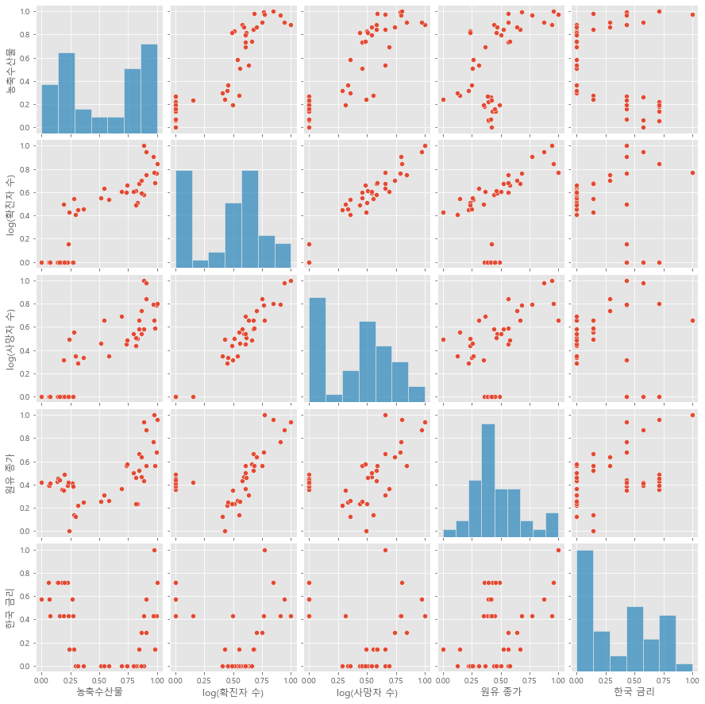

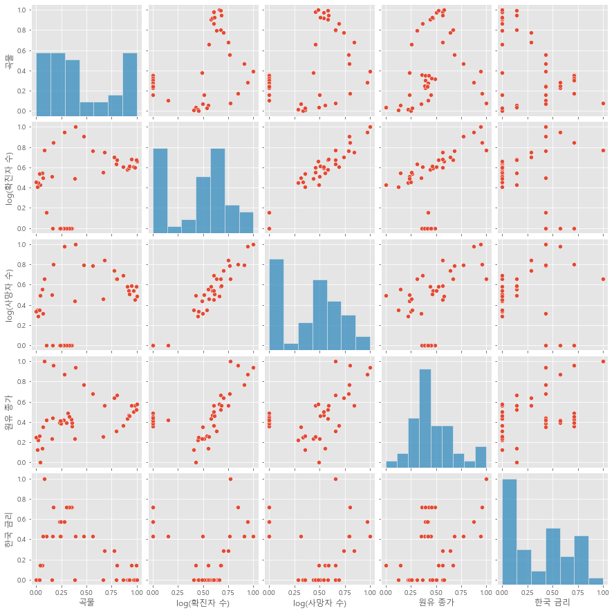

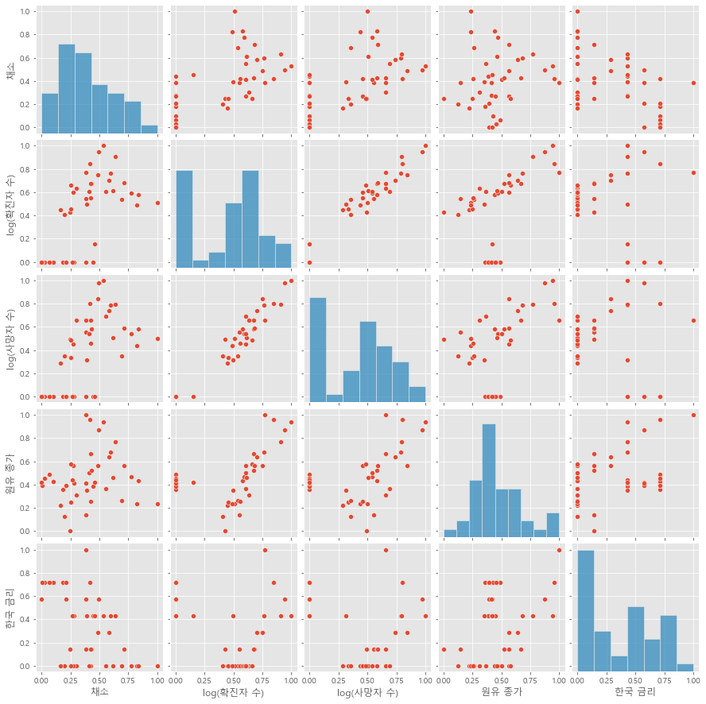

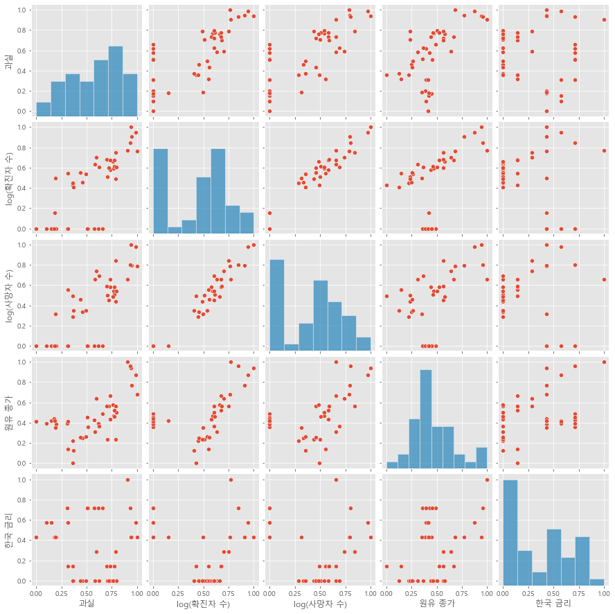

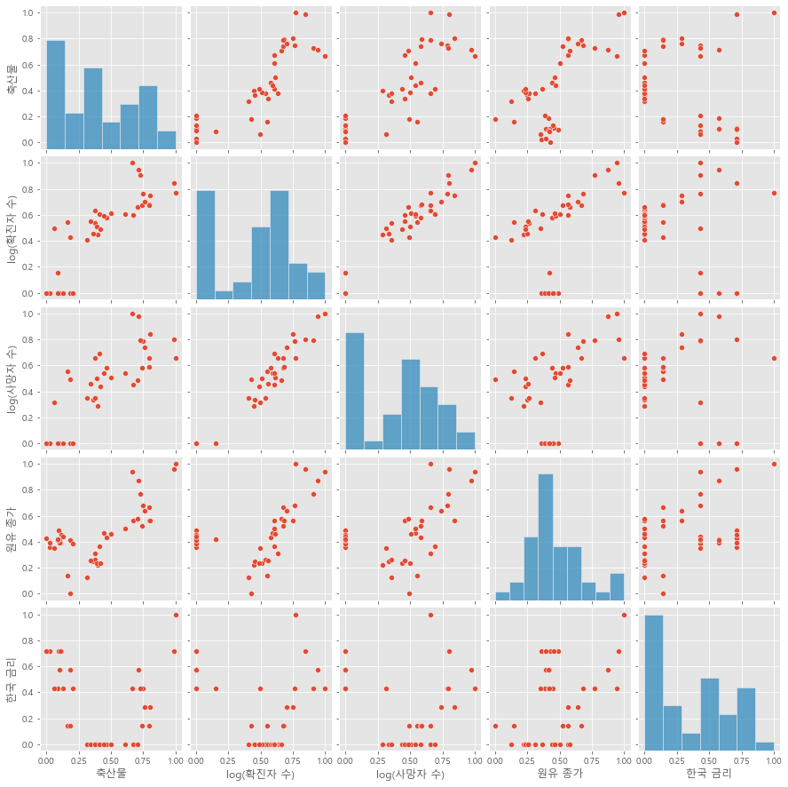

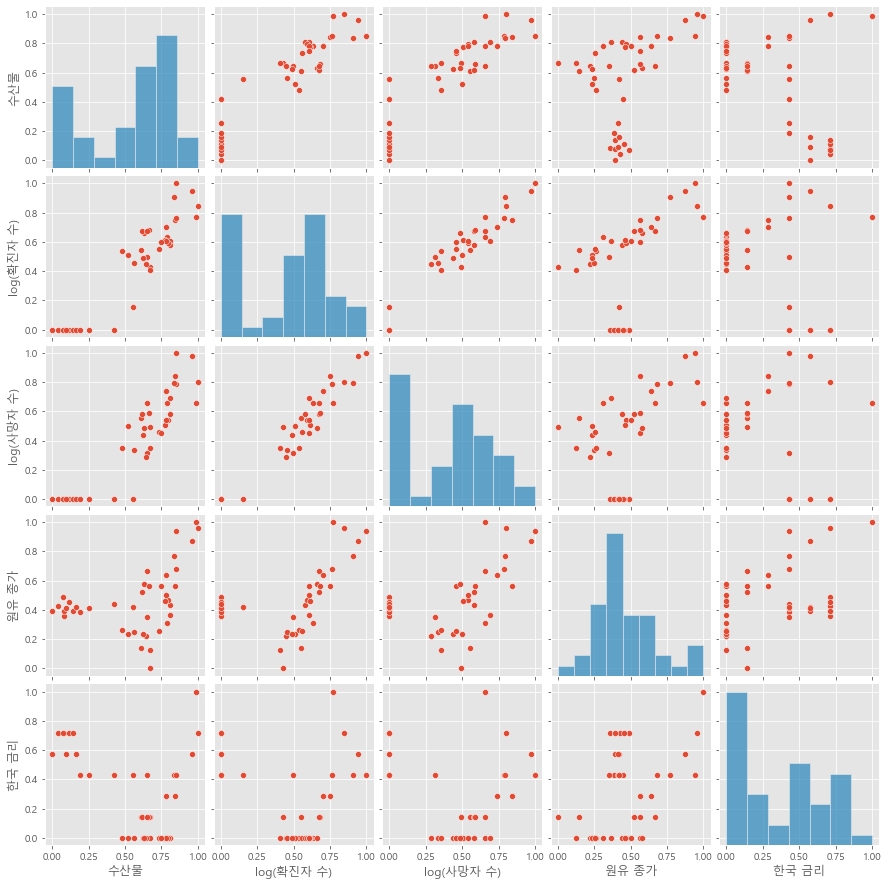

```python
lf_cols = list(scaled_LF.columns[:6])
fac_cols = list(scaled_LF.columns[6:])
for i in range(6):
    cols = [lf_cols[i]]+ fac_cols
    sns.pairplot(scaled_LF[list([lf_cols[i]]+ fac_cols)])
    plt.show()
```

농축수산물 전체, 과실, 축산물, 수산물

- 코로나 확진자, 사망자, 원유 종가와 상관관계가 있어보인다.

곡물, 채소

- 여러 요인들과 관련이 없어 보인다.

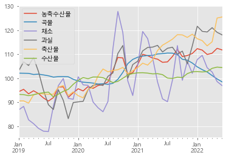

```python
LF_total.iloc[:,:6].plot()
```

농축수산물 전체와 각 분류별 소비자 물가의 변동을 시각화

- 채소, 과실, 축산물의 변동 폭이 크다.

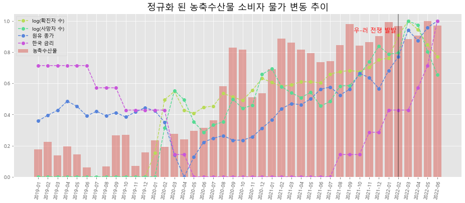

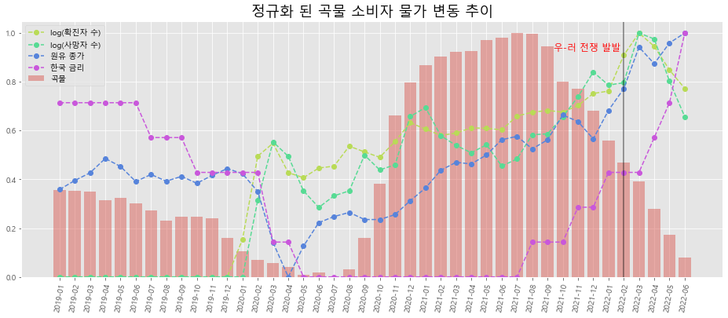

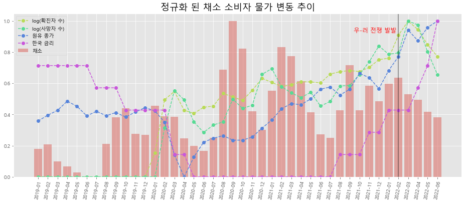

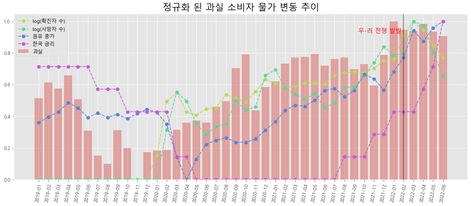

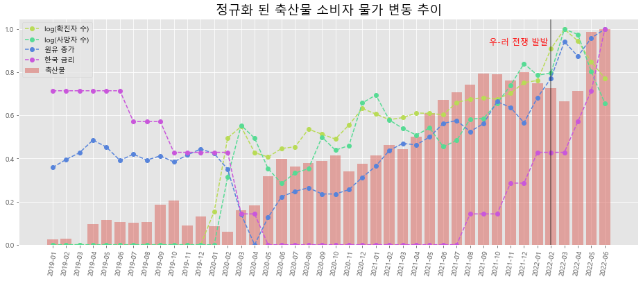

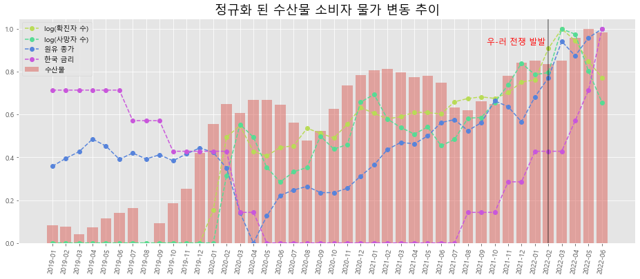

```python
colors = sns.color_palette('hls', 5)

def draw_scaled(scale_df, col):
    plt.figure(figsize=(16,6))
    plt.bar(range(len(scale_df.index)), scale_df[col], alpha = 0.5, color = colors[0])
    plt.xticks(range(len(scale_df.index)), scale_df.index, rotation=80)
    for fac in fac_cols:
        plt.plot(range(len(scale_df.index)),scale_df[fac],
                 'o--', color = colors[fac_cols.index(fac)+1])
    legs = list(scale_df.columns[6:]) +[col]

    plt.legend(legs,loc = 2)

    plt.axvline(x=37, ymin=0, ymax=1.0, color = 'black', alpha = 0.5)
    plt.text(x=37, y = 0.93, s = '우-러 전쟁 발발 ', fontsize = 12, color = 'r', ha = 'right' )
    plt.title('정규화 된 '+ col +' 소비자 물가 변동 추이', fontsize = 18 )
    plt.show()

for col in lf_cols:
    draw_scaled(scaled_LF, col)
```

농축수산물 전체와 각 분류별 소비자 물가지수를 정규화 하고  
코로나 관련 수치들, 원유, 금리 수치들도 정규화 하여 전체 자료의 정규화된 변동을 시각화

곡물 분야를 제외하고 전체적으로 코로나 수치와 원유 종가에 따라 증가하는 경향을 보였다.

농축수산물 전체

- 코로나 발생 이후 지속적으로 증가하였다. 전쟁 발발 직후 감소하는듯 하였으나 증가

곡물

- 변동폭이 적어 의미는 부족하나 2020년 말 급증한 후 다시 감소

채소

- 변동이 컸으며 이 그래프에서도 주기성이 보인다. 코로나 이후 전체적으로 증가한듯 하다.

과실

- 변동이 컸으며 코로나 이후 많은 증가를 보였다.

축산물

- 코로나환자, 사망자의 수치와 유사한 증가 경향을 보이며 코로나 이후 원유 종가와도 연관을 보인다.

수산물

- 실제 변동폭이 적어 정규화된 자료의 의미가 부족하다. 축산물과 유사한 경향을 보인다.

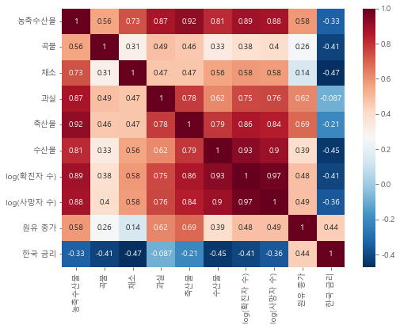

```python
plt.figure(figsize=(8,6))
plt.rcParams['axes.unicode_minus'] = False
sns.heatmap(scaled_LF.corr(), annot= True, cmap='RdBu_r')
```

농축수산물, 하위분류들과 요인들간의 상관관계를 heatmap으로 표시

- 농축수산물의 경우는 코로나 수치와 원유의 가격과 상관관계가 있는것으로 보인다.
- 각 하위 분야
  - 곡물을 제외하고 코로나 수치과 상관관계가 높은 것으로 보이고
  - 과실과 축산물 분야는 원유 가격과 상관관계가 있어 보인다.

### 코로나 확진자 수와 농축수산물 소비자 물가 사이의 관계 상세분석

```python
target_data = LF_total[['농축수산물','확진자 수']]
target_data
```

|  | 농축수산물 | 확진자 수 |
| --- | --- | --- |
| 2019-01 | 94.406 | 0.0 |
| 2019-02 | 95.397 | 0.0 |
| 2019-03 | 93.525 | 0.0 |
| 2019-04 | 94.801 | 0.0 |
| 2019-05 | 93.634 | 0.0 |
| 2019-06 | 91.804 | 0.0 |
| 2019-07 | 90.511 | 0.0 |
| 2019-08 | 91.955 | 0.0 |
| 2019-09 | 96.320 | 0.0 |
| 2019-10 | 96.421 | 0.0 |
| 2019-11 | 92.064 | 0.0 |
| 2019-12 | 93.953 | 0.0 |
| 2020-01 | 95.630 | 11.0 |
| 2020-02 | 94.730 | 2920.0 |
| 2020-03 | 96.570 | 6855.0 |
| 2020-04 | 95.780 | 979.0 |
| 2020-05 | 96.980 | 703.0 |
| 2020-06 | 97.400 | 1331.0 |
| 2020-07 | 98.450 | 1506.0 |
| 2020-08 | 103.300 | 5641.0 |
| 2020-09 | 108.680 | 3865.0 |
| 2020-10 | 108.450 | 2700.0 |
| 2020-11 | 101.740 | 7688.0 |
| 2020-12 | 102.300 | 26527.0 |
| 2021-01 | 105.700 | 17471.0 |
| 2021-02 | 109.970 | 11467.0 |
| 2021-03 | 109.410 | 13415.0 |
| 2021-04 | 108.400 | 18927.0 |
| 2021-05 | 107.940 | 18331.0 |
| 2021-06 | 106.630 | 16623.0 |
| 2021-07 | 106.810 | 41374.0 |
| 2021-08 | 109.060 | 53077.0 |
| 2021-09 | 112.010 | 59857.0 |
| 2021-10 | 109.010 | 53415.0 |
| 2021-11 | 109.470 | 82517.0 |
| 2021-12 | 110.300 | 183596.0 |
| 2022-01 | 112.310 | 214819.0 |
| 2022-02 | 111.720 | 2288500.0 |
| 2022-03 | 109.890 | 9960544.0 |
| 2022-04 | 110.420 | 4142605.0 |
| 2022-05 | 112.450 | 866081.0 |
| 2022-06 | 111.800 | 255909.0 |

```python
target_data['확진자 수'] = np.log10(target_data['확진자 수']+1)
target_data.rename(columns = {'확진자 수': 'log(확진자 수)'}, inplace = True)
target_data
```

|  | 농축수산물 | log(확진자 수) |
| --- | --- | --- |
| 2019-01 | 94.406 | 0.000000 |
| 2019-02 | 95.397 | 0.000000 |
| 2019-03 | 93.525 | 0.000000 |
| 2019-04 | 94.801 | 0.000000 |
| 2019-05 | 93.634 | 0.000000 |
| 2019-06 | 91.804 | 0.000000 |
| 2019-07 | 90.511 | 0.000000 |
| 2019-08 | 91.955 | 0.000000 |
| 2019-09 | 96.320 | 0.000000 |
| 2019-10 | 96.421 | 0.000000 |
| 2019-11 | 92.064 | 0.000000 |
| 2019-12 | 93.953 | 0.000000 |
| 2020-01 | 95.630 | 1.079181 |
| 2020-02 | 94.730 | 3.465532 |
| 2020-03 | 96.570 | 3.836071 |
| 2020-04 | 95.780 | 2.991226 |
| 2020-05 | 96.980 | 2.847573 |
| 2020-06 | 97.400 | 3.124504 |
| 2020-07 | 98.450 | 3.178113 |
| 2020-08 | 103.300 | 3.751433 |
| 2020-09 | 108.680 | 3.587262 |
| 2020-10 | 108.450 | 3.431525 |
| 2020-11 | 101.740 | 3.885870 |
| 2020-12 | 102.300 | 4.423705 |
| 2021-01 | 105.700 | 4.242343 |
| 2021-02 | 109.970 | 4.059488 |
| 2021-03 | 109.410 | 4.127623 |
| 2021-04 | 108.400 | 4.277105 |
| 2021-05 | 107.940 | 4.263210 |
| 2021-06 | 106.630 | 4.220736 |
| 2021-07 | 106.810 | 4.616738 |
| 2021-08 | 109.060 | 4.724915 |
| 2021-09 | 112.010 | 4.777122 |
| 2021-10 | 109.010 | 4.727671 |
| 2021-11 | 109.470 | 4.916549 |
| 2021-12 | 110.300 | 5.263866 |
| 2022-01 | 112.310 | 5.332075 |
| 2022-02 | 111.720 | 6.359551 |
| 2022-03 | 109.890 | 6.998283 |
| 2022-04 | 110.420 | 6.617274 |
| 2022-05 | 112.450 | 5.937559 |
| 2022-06 | 111.800 | 5.408087 |

```python
target_data['log(확진자 수)'] = target_data['log(확진자 수)']*3 + 90
target_data.rename(columns = {'log(확진자 수)': 'log(확진자 수)*3 + 90'}, inplace = True)
target_data
```

|  | 농축수산물 | log(확진자 수)*3 + 90 |
| --- | --- | --- |
| 2019-01 | 94.406 | 90.000000 |
| 2019-02 | 95.397 | 90.000000 |
| 2019-03 | 93.525 | 90.000000 |
| 2019-04 | 94.801 | 90.000000 |
| 2019-05 | 93.634 | 90.000000 |
| 2019-06 | 91.804 | 90.000000 |
| 2019-07 | 90.511 | 90.000000 |
| 2019-08 | 91.955 | 90.000000 |
| 2019-09 | 96.320 | 90.000000 |
| 2019-10 | 96.421 | 90.000000 |
| 2019-11 | 92.064 | 90.000000 |
| 2019-12 | 93.953 | 90.000000 |
| 2020-01 | 95.630 | 93.237544 |
| 2020-02 | 94.730 | 100.396595 |
| 2020-03 | 96.570 | 101.508212 |
| 2020-04 | 95.780 | 98.973678 |
| 2020-05 | 96.980 | 98.542718 |
| 2020-06 | 97.400 | 99.373513 |
| 2020-07 | 98.450 | 99.534340 |
| 2020-08 | 103.300 | 101.254299 |
| 2020-09 | 108.680 | 100.761786 |
| 2020-10 | 108.450 | 100.294574 |
| 2020-11 | 101.740 | 101.657610 |
| 2020-12 | 102.300 | 103.271114 |
| 2021-01 | 105.700 | 102.727028 |
| 2021-02 | 109.970 | 102.178463 |
| 2021-03 | 109.410 | 102.382869 |
| 2021-04 | 108.400 | 102.831314 |
| 2021-05 | 107.940 | 102.789630 |
| 2021-06 | 106.630 | 102.662207 |
| 2021-07 | 106.810 | 103.850214 |
| 2021-08 | 109.060 | 104.174744 |
| 2021-09 | 112.010 | 104.331367 |
| 2021-10 | 109.010 | 104.183014 |
| 2021-11 | 109.470 | 104.749646 |
| 2021-12 | 110.300 | 105.791597 |
| 2022-01 | 112.310 | 105.996224 |
| 2022-02 | 111.720 | 109.078653 |
| 2022-03 | 109.890 | 110.994849 |
| 2022-04 | 110.420 | 109.851821 |
| 2022-05 | 112.450 | 107.812677 |
| 2022-06 | 111.800 | 106.224262 |

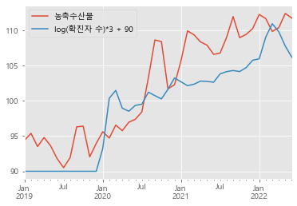

```python
target_data.plot()
```

코로나 확진자 수와 농축수산물의 소비자물가가 함께 증가하는 경향을 보인다.

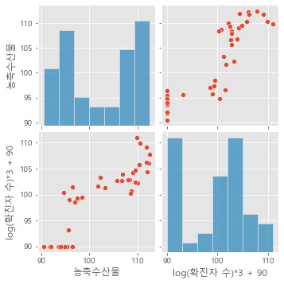

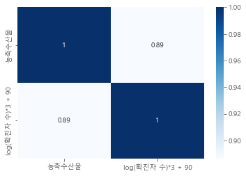

```python
sns.pairplot(target_data)
plt.show()
sns.heatmap(target_data.corr(),annot= True,cmap = 'Blues')
plt.show()
```

##### 농축 수산물 전체 분야의 소비자물가를 분석한 결과

- 해당 지표는 코로나, 원유가격 요인과 상관관계가 있는것으로 파악
- 코로나 확진자수에 의한 영향이 가장 큼

##### 농축 수산물 내 하위 분류의 소비자 물가에 대한 분석

- 채소, 과일, 축산물 분야의 물가 변동이 큼
- 해당 분야는 코로나 발생 이후 많은 증가량을 보였다.

##### 최종결론

- 농축 수산물 분야의 소비자 물가 급등은 코로나 확진자 수 증가와 원유 가격의 인상으로 인해
- 채소, 과일, 축산물 분야가 급등하였기 때문으로 파악된다.